# Final Proj 2

## Scientific Question: Do the genes and proteins that are used for the UV-repair pathway in humans (specifically in nucleotide excision repair) have a high correlation in terms of gene similarity and protein structure with each other?

Background Information: There are two main categories of nucleotide excision repair: global genome nucleotide excision repair (GG-NER), and transcription-coupled nucleotide excision repair (TC-NER). The genes responsible for the processes wildly vary however.

Data: I found the genes and proteins responsible for NER on a separate website (https://www.mdanderson.org/documents/Labs/Wood-Laboratory/human-dna-repair-genes.html). I used NCBI and PDB to find the genes of interest. I found the genes and proteins responsible for NER on a separate website. I downloaded the files necessary through NCBI and PDB however. I used the genes ERCC2,ERCC3,XPC,XPA,and LIG1 as my genes/proteins of interest. They all have different functions except for XPC and XPA which both bind DNA.

## Hypothesis: If the proteins, and thus genes, responsible for nucleotide excision repair each have completely different functions and structures, then the proteins and the genes responsible for them in nucleotide excision repair will not have a high sequence homology or structural homology in relation to each other.

# Part 1: Load Packages

Matplotlib: This is used to plot the heatmap. It is a package that allows plots of various sizes. It can be used to plot scatter plots for example. They have different functions that allow for easier creations of plots. https://matplotlib.org/

Numpy: Numpy is used for mathematical equations. It can create large arrays and other useful information holders. Numpy is used in many python creations because it is so simply. We learned this in Datacamp and have used it before. https://numpy.org/

Nglview: This is a package for web based visualization. I used this to visualize the different proteins. It directly came from the PDB database. This is useful for easy visualization. It also does not require people to download a file if they wish to visualize a protein.https://nglviewer.org/

```python
from Bio import SeqIO
import numpy as np
import matplotlib.pyplot as plt
from Bio import pairwise2
from Bio.Seq import Seq
import nglview
from Bio.PDB import *
from Bio.PDB.PDBParser import PDBParser
```

# Part 2: Pairwise Sequence Alignment

Pairwise sequence alignment compares the individual nucleotides in the different genes with each other You gets a pairwise alignment score that shows how many nucleotides matched.

```python
#Reads in the fasta file using SeqIO, Fasta is a global variable
Fasta = list(SeqIO.parse("DataFiles.fasta", "fasta"))
#Sets global variable size to the length of Fasta
size = len(Fasta)
#code check
#print(size)
#creates empty array of size,size as the global variable alignments_score
alignments_score = np.empty(shape=(size,size))

#Nested for loop to do pairwise sequence alignment for each pair of kinases
def pairwise_seq_heatmap(my_numpy_array, size):
    # loops over the kinases
    for i in range(size):
        #loops over the kinases again
        for j in range(size):
        # x,y are local variables that define two sequences to be aligned.
            X = Fasta[i].seq
            Y = Fasta[j].seq
            # Code Check below
            #print(Fasta[i].id)

        # Get a list of the global alignments between the two sequences ACGGGT and ACG
        # No parameters. Identical characters have score of 1, else 0.
        # No gap penalties.
        #my_numpy_array is a new created array that contains the global alignment scores
        #that is a local variable
            my_numpy_array[i,j] = int(pairwise2.align.globalxx(X, Y, score_only=True))
#returns array
    return my_numpy_array
#sets a new array with the pairwise sequence alignments as a global variable
My_alignment_Scores = pairwise_seq_heatmap(alignments_score, size)
#code check
print(My_alignment_Scores)
```

```
[[35770. 20683. 19536. 16537. 17749.]
 [20683. 29120. 17748. 15317. 16207.]
 [19536. 17748. 26320. 14884. 15875.]
 [16537. 15317. 14884. 20811. 14047.]
 [17749. 16207. 15875. 14047. 22750.]]
```

# Part 3: Heat map

A heat map is used to compare the similarities of the proteins/RNA through color visualization. A color bar will be added to show the degree of correlations of the proteins. This plot was used to visually analyze the alignment scores with each other. A higher or brighter color will mean that the two genes had more nucleotide homology.

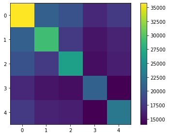

```python
#Sets a figure and ax variable equal to plt.subplots()
fig, ax = plt.subplots()

#Instructs the heat map to show the axes
im = ax.imshow(My_alignment_Scores)

# Add a colorbar to the right of the heatmap
cbar = ax.figure.colorbar(im)

#Actually show the heatplot
plt.imshow(My_alignment_Scores)

#Set the X-axis & Y-Axis ticks
ax.set_xticks(np.arange(size))
ax.set_yticks(np.arange(size))

# Show the heatmap
fig.tight_layout()
plt.show()
```